# Assignment 2

Data Visualizaiton (DS4073)

### Description

Please complete the codes such that they can get the same outputs. Submit the **.html** and **.rmd** documents to iSpace.

#### 1. Prepare the data and use the pie chart to show the proportion of each type of pets.

**Hint**: `scale_fill_brewer()` may help. Notice the color mapping.

```r
# Define the dataframe named 'plotdata'
# Write your code here
```

```
##            pet  num
## 1          Dog 1600
## 2          Cat 2100
## 3      Psyduck  900
## 4 Fragrant pig  600
## 5       Lizard  450
```

```r
# Write your code here
```

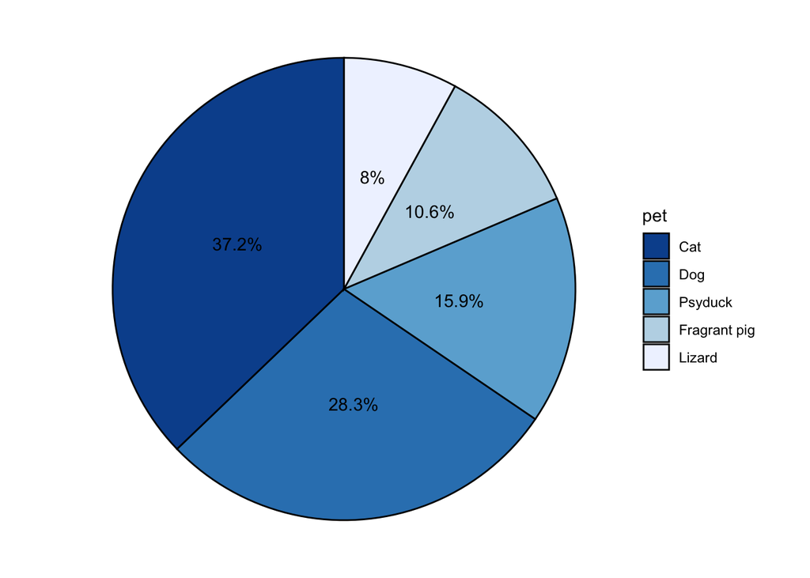

#### 2. Use the dataset CPS85 from the package mosaicData. Please count the number of females and males in each sector.

**Hint**: You can copy the command `View(CPS85)` in the console to view the tabular data of CPS85.

```r
# Loading data
data(CPS85, package = "mosaicData")
# Count the number of females and males in each sector
# Write your code here
```

```
##      sector sex  n
## 1  clerical   F 76
## 2  clerical   M 21
## 3     const   M 20
## 4     manag   F 21
## 5     manag   M 34
## 6     manuf   F 24
## 7     manuf   M 44
## 8     other   F  6
## 9     other   M 62
## 10     prof   F 52
## 11     prof   M 53
## 12    sales   F 17
## 13    sales   M 21
## 14  service   F 49
## 15  service   M 34
```

Construct a stacked bar chart to show the number of females and males in each sectors.

**Hint**: `geom_text()` may help you show the numbers in the bars. The two color values `#C73C68` and `B6C468` can help.

```r
# Write your code here
```

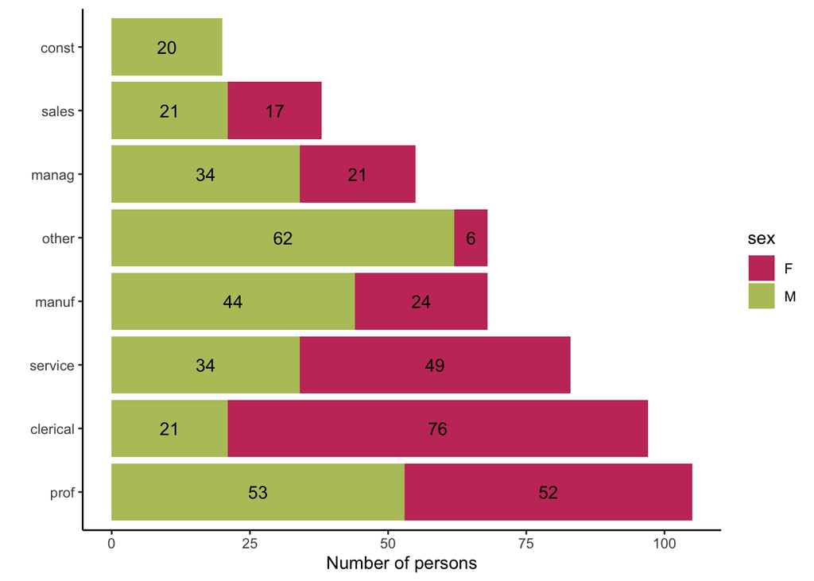

**Hint**: `geom_smooth()` may help you to construct the linear regression line. You can specify the points with `size = 1`, `alpha = 0.4`, the fitting line with `size = 0.5`, `color = "tomato"`.

```r
# Write your code here
```

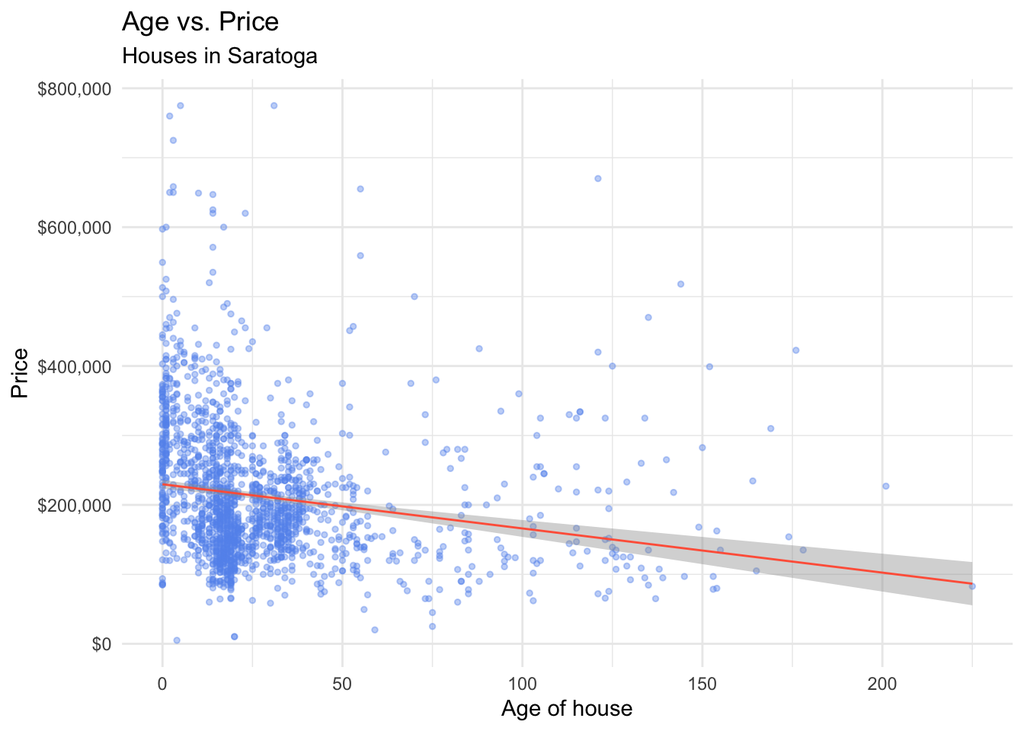

#### 4. Based on the dataset `SaratogaHouses` from package `mosaicData`, please draw the boxplot for the house price by number of rooms.

**Hint**: Transparency of boxplot is specified as `alpha = 0.5`.

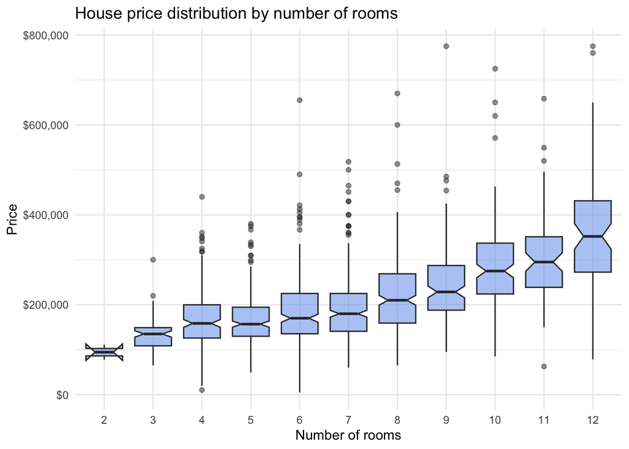

```r
# Plotting a boxplot for the house price by number of rooms
# Write your code here
```

#### 5. Please plot the Cleveland dot chart for the percentage of receipts in GDP by country. The datasset `newgdp` from the package `CGPfunctions` records current receipts of fifteen national governments as a percentage of gross domestic product. You can read more detail by running the code `??newgdp` in the console.

1. Selecting all the data in year 1979 and mutate the GDP into percentage.
2. Plot the Cleveland dot chart for GDP percentage by country.

Hint: Please install the package `CGPfunctions` if you haven’t installed. (No need to write the install code in the R code chunk below.) The range of x is (0.2, 0.6).

```r
# Loading data
data(newgdp, package = "CGPfunctions")
# Write your code here
```

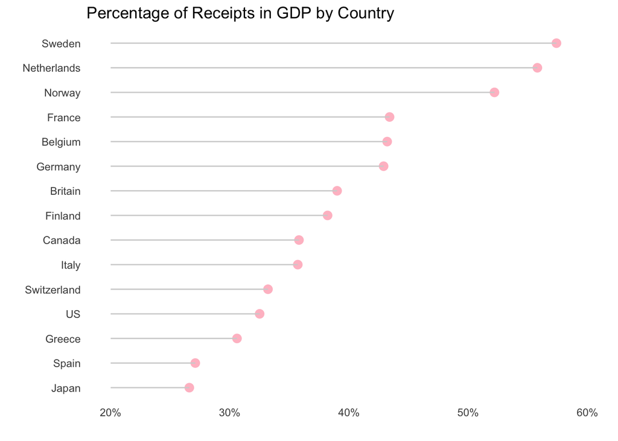